# sentimentAnalysis: Tidy analysis

C.J. Liu

1/29/2017

Learning codes from the [David Robinson](http://varianceexplained.org/r/yelp-sentiment/) sentiment analysis. The main packages used are `tidytext` and `tidyverse` suits. The data was downloaded from [Yelp](https://www.yelp.com/dataset_challenge).

## 0.1 Load libraries

```r
suppressMessages(require(tidyverse))
suppressMessages(require(tidytext))
suppressMessages(require(stringr))
suppressMessages(require(jsonlite))
```

## 0.2 Read data into data frame

```r
reviewFile <- "yelp_academic_dataset_review.json"

reviewLines <- read_lines(reviewFile, n_max = 200000, progress = F)
```

The fastest way to process is to combine into a single JSON string and use `fromJSON` and `flatten`

```r
# stringr::str_c combined character vector into a big json string
reviewsCombined <- str_c('[', str_c(reviewLines, collapse = ', '), ']')

# fromJSON convert one row json string into data frame
# tbl_df comvert data.frame to table source
reviews <- fromJSON(reviewsCombined) %>% flatten() %>% tbl_df()
reviews
```

```
## # A tibble: 200,000 × 10
##                 review_id                user_id            business_id
## *                   <chr>                  <chr>                  <chr>
## 1  NxL8SIC5yqOdnlXCg18IBg KpkOkG6RIf4Ra25Lhhxf1A 2aFiy99vNLklCx3T_tGS9A
## 2  pXbbIgOXvLuTi_SPs1hQEQ bQ7fQq1otn9hKX-gXRsrgA 2aFiy99vNLklCx3T_tGS9A
## 3  wslW2Lu4NYylb1jEapAGsw r1NUhdNmL6yU9Bn-Yx6FTw 2aFiy99vNLklCx3T_tGS9A
## 4  GP6YEearUWrzPtQYSF1vVg aW3ix1KNZAvoM8q-WghA3Q 2LfIuF3_sX6uwe-IR-P0jQ
## 5  25RlYGq2s5qShi-pn3ufVA YOo-Cip8HqvKp_p9nEGphw 2LfIuF3_sX6uwe-IR-P0jQ
## 6  Uf1Ki1yyH_JDKhLvn2e4FQ bgl3j8yJcRO-00NkUYsXGQ 2LfIuF3_sX6uwe-IR-P0jQ
## 7  oFmVZh-La7SuvpHrH_Al4Q CWKF9de-nskLYEqDDCfubg 2LfIuF3_sX6uwe-IR-P0jQ
## 8  bRvdVt88MJ_YMTlLbjDLxQ GJ7PTY7huYORFKKg3db3Gw 2LfIuF3_sX6uwe-IR-P0jQ
## 9  zNUSxqflZKgKD1NQH3jdFA rxqp9eXZj1jYTn0UIsm3Hg 2LfIuF3_sX6uwe-IR-P0jQ
## 10 LkP1l7sZIwOV6IKNLqQp_A UU0nHQtHPMAfLidk8tOHTg 2LfIuF3_sX6uwe-IR-P0jQ
## # ... with 199,990 more rows, and 7 more variables: stars <int>,
## #   date <chr>, text <chr>, useful <int>, funny <int>, cool <int>,
## #   type <chr>
```

Use `unnest_tokens` to turn each reviews into one-row-per-term-document

```r
# remove stop words and '--'
reviewWords <- reviews %>% select(review_id, business_id, stars, text) %>% unnest_tokens(word, text) %>% filter(! word %in% stop_words$word, str_detect(word, "^[a-z']+$"))
```

Use AFINN lexicon which provides a positivity score for each word. -5 most negative and 5 for most positive. `sentiments` in `tidytext` provides serveral lexicons.

```r
AFINN <- sentiments %>% filter(lexicon == 'AFINN') %>% select(word, afinn_score = score)
```

inner_join operation AFINN with reviewWords

```r
reviewsSentiment <- reviewWords %>% inner_join(AFINN, by = "word") %>% group_by(review_id, stars) %>% summarise(sentiment = mean(afinn_score))
```

We have an average sentiment alongside the star ratings.

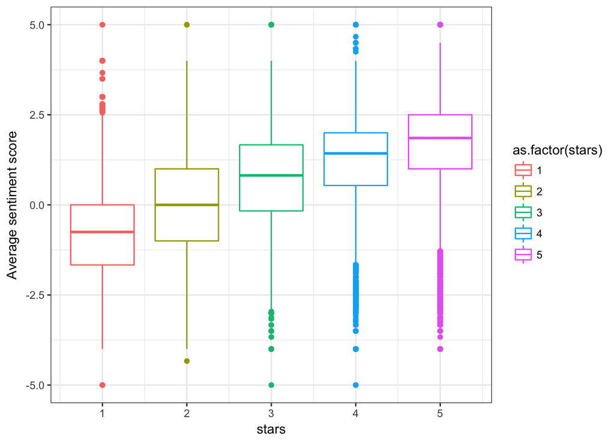

```r
theme_set(theme_bw())

ggplot(reviewsSentiment, aes(stars, sentiment, group = stars)) +
  geom_boxplot(aes(color = as.factor(stars))) +
  ylab("Average sentiment score")
```

*The sentiment scores are certainly correlated with positivity ratings. But we do see that there’s a large amount of predicion error- some 5-star reviews have a highly negative sentiment score, and vise versa.*

*The algorithm works at the word level, if we want to improve approach we need to figure out which words are suggestive of positive reviews and which are negative?*

*To examine this, let’s create a per-word summary, and see which words tend to appear in positive or negative reviews.*

```r
reviewWordsCounted <- reviewWords %>% count(review_id, business_id, stars, word) %>% ungroup()
reviewWordsCounted
```

```
## # A tibble: 7,358,154 × 5
##                 review_id            business_id stars     word     n
##                     <chr>                  <chr> <int>    <chr> <int>
## 1  ___iDWC9iXf9R6BtxXgNcQ 9OHPCG0epevEpj-H7COfUQ     5 barbecue     1
## 2  ___iDWC9iXf9R6BtxXgNcQ 9OHPCG0epevEpj-H7COfUQ     5    bread     1
## 3  ___iDWC9iXf9R6BtxXgNcQ 9OHPCG0epevEpj-H7COfUQ     5  chicken     1
## 4  ___iDWC9iXf9R6BtxXgNcQ 9OHPCG0epevEpj-H7COfUQ     5     corn     1
## 5  ___iDWC9iXf9R6BtxXgNcQ 9OHPCG0epevEpj-H7COfUQ     5     fast     1
## 6  ___iDWC9iXf9R6BtxXgNcQ 9OHPCG0epevEpj-H7COfUQ     5  forward     1
## 7  ___iDWC9iXf9R6BtxXgNcQ 9OHPCG0epevEpj-H7COfUQ     5     pork     1
## 8  ___iDWC9iXf9R6BtxXgNcQ 9OHPCG0epevEpj-H7COfUQ     5 portions     1
## 9  ___iDWC9iXf9R6BtxXgNcQ 9OHPCG0epevEpj-H7COfUQ     5   pulled     1
## 10 ___iDWC9iXf9R6BtxXgNcQ 9OHPCG0epevEpj-H7COfUQ     5     ribs     1
## # ... with 7,358,144 more rows
```

```r
wordSummaries <- reviewWordsCounted %>%  group_by(word) %>% summarize(business = n_distinct(business_id), reviews = n(), uses = sum(n), average_stars = mean(stars)) %>% ungroup()
wordSummaries
```

```
## # A tibble: 161,605 × 5
##         word business reviews  uses average_stars
##        <chr>    <int>   <int> <int>         <dbl>
## 1  a'changed        1       1     1      3.000000
## 2     a'fare        1       4     4      3.250000
## 3      a'hem        1       1     1      5.000000
## 4     a'ight        1       1     1      3.000000
## 5       a'la        4       4     5      3.750000
## 6  a'manager        1       1     1      1.000000
## 7   a'propos        1       1     2      5.000000
## 8     a'roma        1       1     2      4.000000
## 9         aa       38      46    65      4.065217
## 10      aa's        1       2     2      4.500000
## # ... with 161,595 more rows
```

We can start by looking only at words that appear in at least 200 (out of 200,000) reviews. Both because rare words will have noisier measurement (a few good or bad reviews could shift the balance), and because they’re less likely to be useful in classifying future reviews or text. I also filter for ones that appear in at least 10 businesses (others are likely to be specific to a particular restaurant)

```r
wordSummariesFiltered <- wordSummaries %>% filter(reviews >=200, business >= 10)
wordSummariesFiltered
```

```
## # A tibble: 5,120 × 5
##          word business reviews  uses average_stars
##         <chr>    <int>   <int> <int>         <dbl>
## 1          ab      417     557   613      3.743268
## 2       abend      316     640   809      3.846875
## 3      abends      211     302   319      3.854305
## 4        aber     1161    3955  6481      3.601011
## 5     ability      527     552   570      3.927536
## 6     absolut      396     545   615      3.959633
## 7    absolute     1149    1290  1342      3.624031
## 8  absolutely     4485    6174  6578      3.750729
## 9   abundance      201     210   214      3.661905
## 10         ac      422     566   820      3.362191
## # ... with 5,110 more rows
```

What were the most positive and negative words?

```r
wordSummariesFiltered %>% arrange(desc(average_stars))
```

```
## # A tibble: 5,120 × 5
##           word business reviews  uses average_stars
##          <chr>    <int>   <int> <int>         <dbl>
## 1      listens      310     360   364      4.791667
## 2     crossfit       82     309   689      4.754045
## 3   meticulous      174     200   206      4.685000
## 4        goals      204     266   305      4.676692
## 5     workouts      191     328   426      4.673780
## 6     talented      614     773   808      4.632600
## 7   passionate      440     482   497      4.628631
## 8     exceeded      312     337   339      4.626113
## 9   supportive      190     221   235      4.619910
## 10 compliments      595     713   725      4.617111
## # ... with 5,110 more rows
```

```r
wordSummariesFiltered %>% arrange(average_stars)
```

```
## # A tibble: 5,120 × 5
##              word business reviews  uses average_stars
##             <chr>    <int>   <int> <int>         <dbl>
## 1  unprofessional     1129    1308  1425      1.272171
## 2     incompetent      290     305   318      1.311475
## 3            scam      386     452   538      1.338496
## 4       disgusted      219     223   233      1.358744
## 5          rudely      345     359   382      1.403900
## 6          refund     1116    1315  1801      1.453232
## 7             bbb      204     233   295      1.459227
## 8         refused     1028    1128  1245      1.491135
## 9            lied      296     307   335      1.511401
## 10          worst     3466    4698  5146      1.522563
## # ... with 5,110 more rows
```

Also makes a lot of sense. We can also plot positivity by frequency:

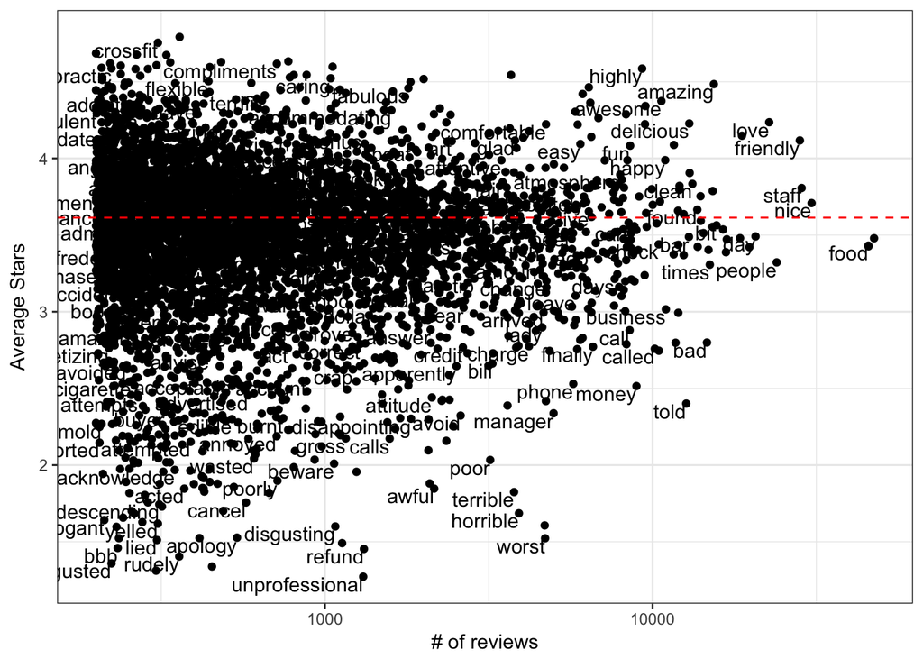

```r
ggplot(wordSummariesFiltered, aes(reviews, average_stars)) +
  geom_point() +
  geom_text(aes(label = word), check_overlap = T, vjust = 1, hjust = 1) +
  scale_x_log10() +
  geom_hline(yintercept = mean(reviews$stars), color = 'red', lty = 2) +
  xlab("# of reviews") +
  ylab("Average Stars")
```

Combine and compare the two datasets with inner_join.

```r
wordsAFINN <- wordSummariesFiltered %>% inner_join(AFINN, by = 'word')
wordsAFINN
```

```
## # A tibble: 556 × 6
##            word business reviews  uses average_stars afinn_score
##           <chr>    <int>   <int> <int>         <dbl>       <int>
## 1       ability      527     552   570      3.927536           2
## 2        accept      773     835   910      2.937725           1
## 3      accepted      378     390   411      2.979487           1
## 4      accident      480     540   606      3.679630          -2
## 5  accidentally      283     295   299      3.166102          -2
## 6        active      296     346   398      3.933526           1
## 7      adequate      417     450   466      3.042222           1
## 8         admit     1211    1357  1391      3.549742          -1
## 9      adorable      547     657   699      4.316591           3
## 10        adore      237     249   254      4.309237           3
## # ... with 546 more rows
```

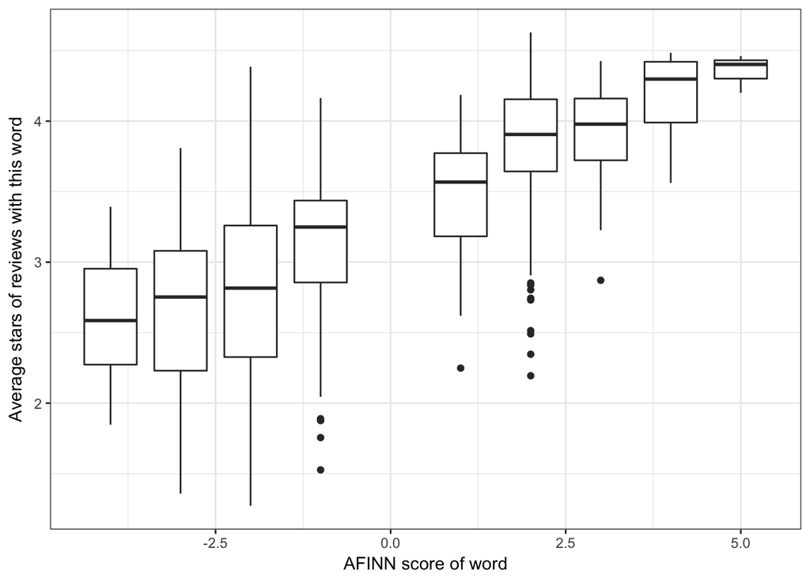

```r
ggplot(wordsAFINN, aes(afinn_score, average_stars, group = afinn_score)) +
  geom_boxplot() +
  xlab("AFINN score of word") +
  ylab("Average stars of reviews with this word")
```

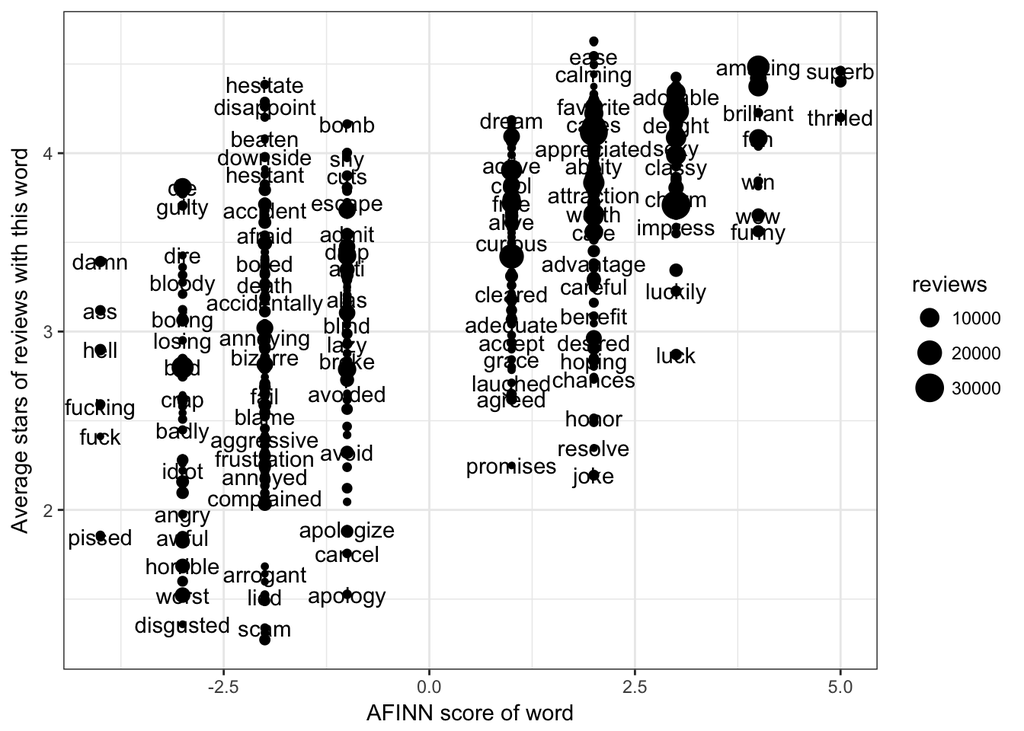

```r
ggplot(wordsAFINN, aes(afinn_score, average_stars, group = afinn_score)) +
  geom_point(aes(size = reviews)) +
  geom_text(aes(label = word), check_overlap = T) +
  xlab("AFINN score of word") +
  ylab("Average stars of reviews with this word")
```

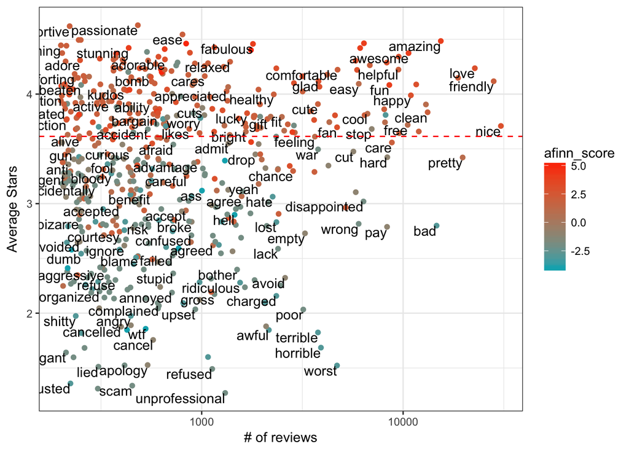

```r
ggplot(wordsAFINN, aes(reviews, average_stars)) +
  geom_point(aes(color = afinn_score)) +
  geom_text(aes(label = word), check_overlap = T, vjust = 1, hjust = 1) +
  scale_color_gradient(low = "#00AFBB", high = "#FC3E07") +
  scale_x_log10() +
  geom_hline(yintercept = mean(reviews$stars), color = 'red', lty = 2) +
  xlab("# of reviews") +
  ylab("Average Stars")
```